# Untitled

# Pruning

Next, we consider whether **pruning** the tree might lead to improved results. The function `cv.tree()` performs cross-validation in order to determine the optimal level of tree complexity; cost complexity pruning is used in order to select a sequence of trees for consideration. We use the argument `FUN = prune.misclass` in order to indicate that we want the **classification error rate** as our cost function to guide the cross-validation and pruning process, rather than the default for the `cv.tree()` function, which is `deviance`. The `cv.tree()` function reports the number of terminal nodes of each tree considered (size) as well as the corresponding error rate and the value of the cost-complexity parameter used ($k$, which corresponds to $\alpha$ in the equation we saw in lecture).

```r
set.seed(3)
cv_carseats = cv.tree(tree_carseats, FUN = prune.misclass)
```

Note that, despite the name, the `dev` field corresponds to the **cross-validation error rate** in this instance. Let’s plot the error rate as a function of size:

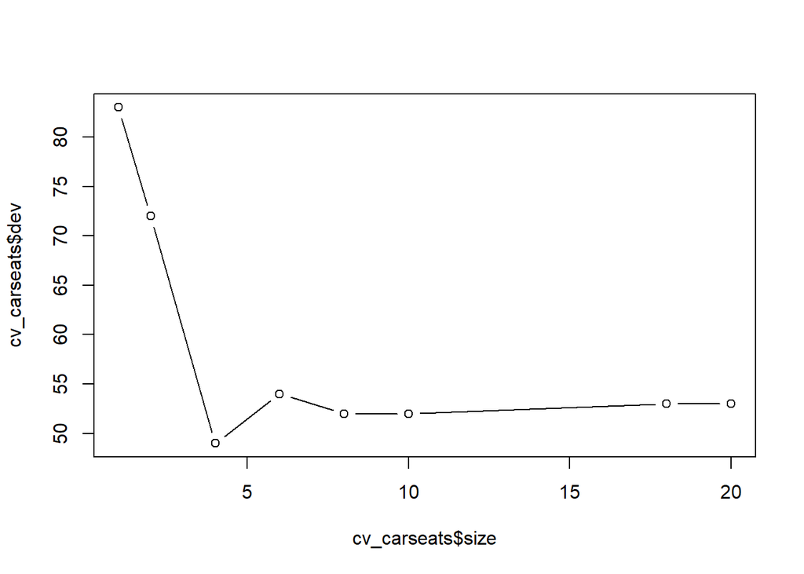

```r
plot(cv_carseats$size, cv_carseats$dev, type = "b")
```

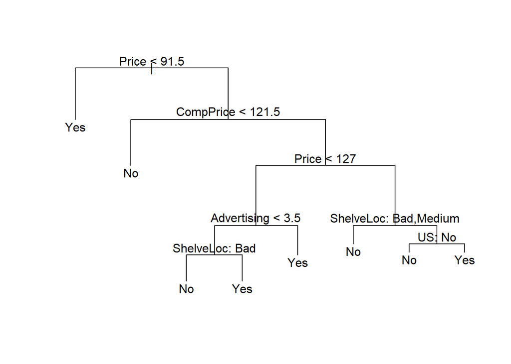

```r
prune_carseats = prune.misclass(tree_carseats, best = 7)
plot(prune_carseats)
text(prune_carseats, pretty = 0)
```

How well does this pruned tree perform on the test data set? Once again, we can apply the `predict()` function top find out:

```r
tree_pred = predict(prune_carseats, test, type = "class")
table(tree_pred, test$High)
```

```
##
## tree_pred No Yes
##       No  83  24
##       Yes 36  57
```